# Introduction to agData

An R package with FAO, USDA, STATCAN and ISAAA data

[figure not shown]

# Data Sources

- `FAO` Food and Agriculture Organization of the United Nations fao.org/faostat/
- `STATCAN` Statistics Canada statcan.gc.ca/
- `USDA` United States Department of Agriculture usda.gov/
- `ISAAA` International Service for the Acquisition of Agri-biotech Applications isaaa.org/

# Instalation

```r
devtools::install_github("derekmichaelwright/agData")
```

```r
library(agData) # Loads: tidyverse, ggpubr, ggbeeswarm, ggrepel
```

This will also the load the following packages: `tidyverse`, `ggpubr`, `ggbeeswarm` & `ggrepel`.

# Data Sets & Functions

- theme_agData()
- agData_FAO_Country_Table
- agData_FAO_Region_Table
- agData_FAO_Crops
- agData_FAO_Crops2
- agData_FAO_Fertilizers
- agData_FAO_LandUse
- agData_FAO_Livestock
- agData_FAO_Population
- agData_FAO_Trade
- agData_STATCAN_Region_Table
- agData_STATCAN_Beehives
- agData_STATCAN_Crops
- agData_STATCAN_FarmLand_Crops
- agData_STATCAN_FarmLand_NoTill
- agData_STATCAN_FarmLand_Size
- agData_STATCAN_FarmLand_Use
- agData_STATCAN_Livestock
- agData_STATCAN_Population
- agData_USDA_Crops
- agData_USDA_GE_Crops
- agData_USDA_TFP
- agData_ISAAA_Area
- agData_ISAAA_Country
- agData_ISAAA_Crop
- agData_ISAAA_CropPercent
- agData_ISAAA_DVDDVG
- agData_ISAAA_Value
- agData_UK_Yields
- agData_MaizeContest
- agData_PeopleInAg
- agData_PopFert

# theme_agData

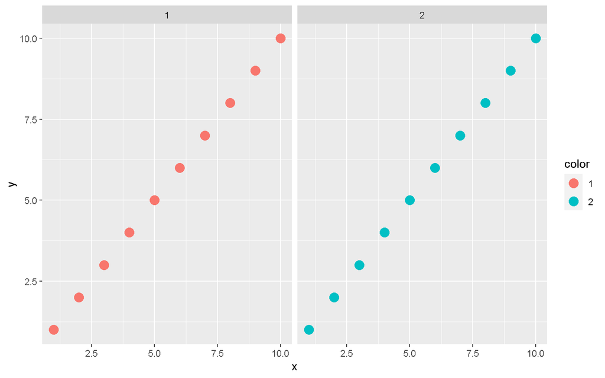

```r
xx <- data.frame(x = 1:10, y = 1:10, color = rep(c("1","2"), times = 5, each = 2))
mp <- ggplot(xx, aes(x = x, y = y, color = color)) +
  geom_point(size = 4) + facet_grid(.~color)
mp
```

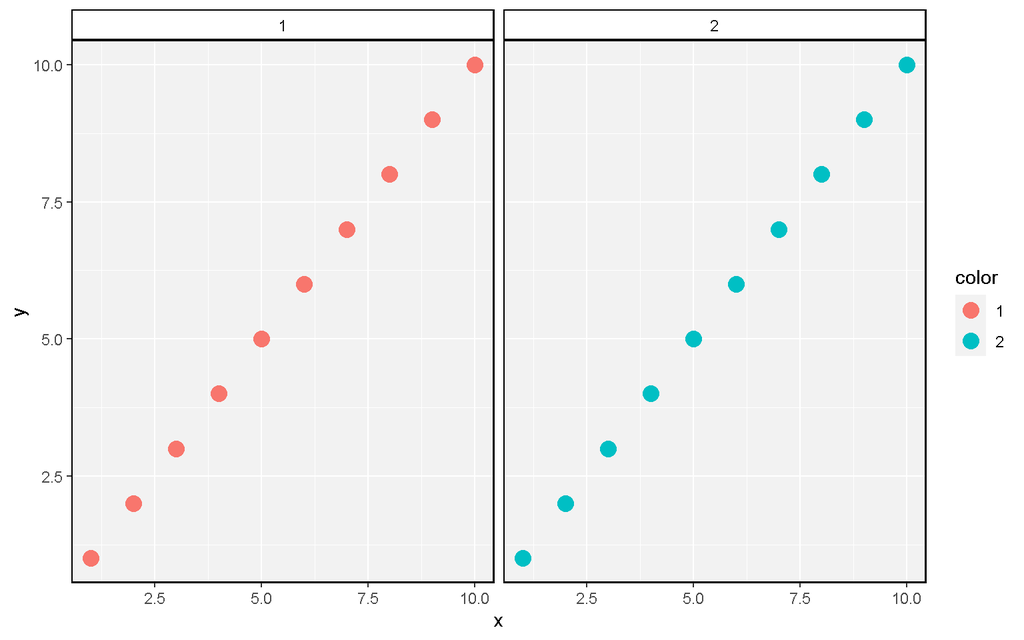

```r
mp + theme_agData()
```

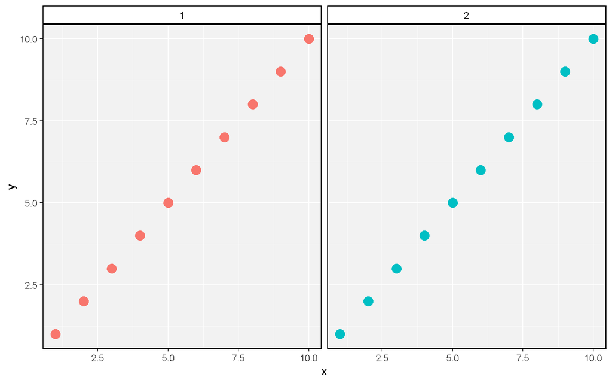

```r
mp + theme_agData(legend.position = "none")
```

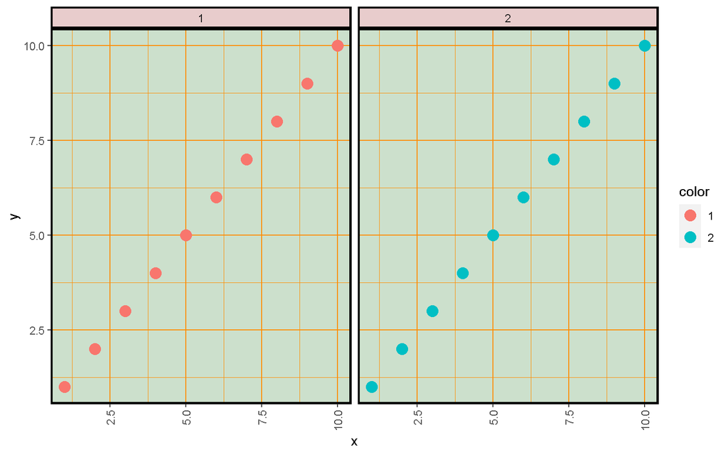

```r
mp + theme_agData(linesize = 1.5,
                  bgFill = alpha("darkgreen",0.2),
                  stripFill = alpha("darkred",0.2),
                  lineColor = "darkorange",
                  axis.text.x = element_text(angle = 90, hjust = 1, vjust = 0.5))
```

# agData_FAO_Country_Table

```r
DT::datatable(agData_FAO_Country_Table)
```

|  | FAO_TABLE_NAME | Country | ISO2 | ISO3 | Lat | Lon | Region | SubRegion | DVDDVG |
| --- | --- | --- | --- | --- | --- | --- | --- | --- | --- |
| 1 | Afghanistan | Afghanistan | AF | AFG | 33.83523216 | 66.00473115 | Asia | Southern Asia | Developing |
| 2 | Åland Islands | Åland Islands | AX | ALA |  |  | Europe | Northern Europe | Developed |
| 3 | Albania | Albania | AL | ALB | 41.14245128 | 20.04983034 | Europe | Southern Europe | Developed |
| 4 | Algeria | Algeria | DZ | DZA | 28.15893844 | 2.61732102 | Africa | Northern Africa | Developing |
| 5 | American Samoa | American Samoa | AS | ASM | -14.30448922 | -170.7180186 | Oceania | Polynesia | Developing |
| 6 | Andorra | Andorra | AD | AND | 42.54229174 | 1.56053368 | Europe | Southern Europe | Developed |
| 7 | Angola | Angola | AO | AGO | -12.29336112 | 17.53736149 | Africa | Middle Africa | Developing |
| 8 | Anguilla | Anguilla | AI | AIA | 18.22396692 | -63.06498464 | Americas | Caribbean | Developing |
| 9 | Antigua and Barbuda | Antigua and Barbuda | AG | ATG | 17.27754256 | -61.7946956 | Americas | Caribbean | Developing |
| 10 | Argentina | Argentina | AR | ARG | -35.38135347 | -65.17980881 | Americas | South America | Developing |

[output cut: 243 more lines]

# agData_FAO_Region_Table

```r
DT::datatable(agData_FAO_Region_Table)
```

|  | FAO_TABLE_NAME | SubRegion | Region |
| --- | --- | --- | --- |
| 1 | South America | South America | Americas |
| 2 | Central America | Central America | Americas |
| 3 | Caribbean | Caribbean | Americas |
| 4 | Northern America | Northern America | Americas |
| 5 | Western Europe | Western Europe | Europe |
| 6 | Southern Europe | Southern Europe | Europe |
| 7 | Northern Europe | Northern Europe | Europe |
| 8 | Eastern Europe | Eastern Europe | Europe |
| 9 | Western Africa | Western Africa | Africa |
| 10 | Northern Africa | Northern Africa | Africa |

[output cut: 19 more lines]

# agData_FAO_Crops

```r
# Get Data
xx <- agData_FAO_Crops %>% as_tibble()
xx
```

```
## # A tibble: 1,673,790 x 6
##    Area       Year Crop                Measurement    Unit         Value
##    <fct>     <dbl> <chr>               <fct>          <chr>        <dbl>
##  1 Algeria    1961 Almonds, with shell Area harvested hectares 13300
##  2 Algeria    1961 Almonds, with shell Yield          t/ha         0.451
##  3 Algeria    1961 Almonds, with shell Production     tonnes    6000
##  4 Argentina  1961 Almonds, with shell Production     tonnes      80
##  5 Bulgaria   1961 Almonds, with shell Production     tonnes    2097
##  6 China      1961 Almonds, with shell Production     tonnes    5000
##  7 Cyprus     1961 Almonds, with shell Area harvested hectares  5800
##  8 Cyprus     1961 Almonds, with shell Yield          t/ha         0.420
##  9 Cyprus     1961 Almonds, with shell Production     tonnes    2438
## 10 France     1961 Almonds, with shell Production     tonnes    3680
## # ... with 1,673,780 more rows
```

```r
# List Measurements
xx %>% distinct(Measurement, Unit)
```

```
## # A tibble: 3 x 2
##   Measurement    Unit
##   <fct>          <chr>
## 1 Area harvested hectares
## 2 Yield          t/ha
## 3 Production     tonnes
```

```r
# List Crops
xx %>% distinct(Crop)
```

```
## # A tibble: 149 x 1
##    Crop
##    <chr>
##  1 Almonds, with shell
##  2 Anise, badian, fennel, coriander
##  3 Apples
##  4 Apricots
##  5 Areca nuts
##  6 Artichokes
##  7 Asparagus
##  8 Avocados
##  9 Bambara beans
## 10 Bananas
## # ... with 139 more rows
```

```r
# Spread data to wide format
xx %>% select(-Unit) %>% spread(Measurement, Value) %>% arrange(Year)
```

```
## # A tibble: 588,252 x 6
##    Area         Year Crop                            `Area harvested` Production  Yield
##    <fct>       <dbl> <chr>                                      <dbl>      <dbl>  <dbl>
##  1 Afghanistan  1961 Apples                                      2220      15100  6.80
##  2 Afghanistan  1961 Apricots                                    4820      32000  6.64
##  3 Afghanistan  1961 Barley                                    350000     378000  1.08
##  4 Afghanistan  1961 Cotton lint                                   NA      17000 NA
##  5 Afghanistan  1961 Cottonseed                                    NA      34000 NA
##  6 Afghanistan  1961 Figs                                        3200       8000  2.5
##  7 Afghanistan  1961 Grapes                                     50000     225000  4.5
##  8 Afghanistan  1961 Linseed                                    46800      17000  0.363
##  9 Afghanistan  1961 Maize                                     500000     700000  1.4
## 10 Afghanistan  1961 Melons, other (inc.cantaloupes)             3300      15700  4.76
## # ... with 588,242 more rows
```

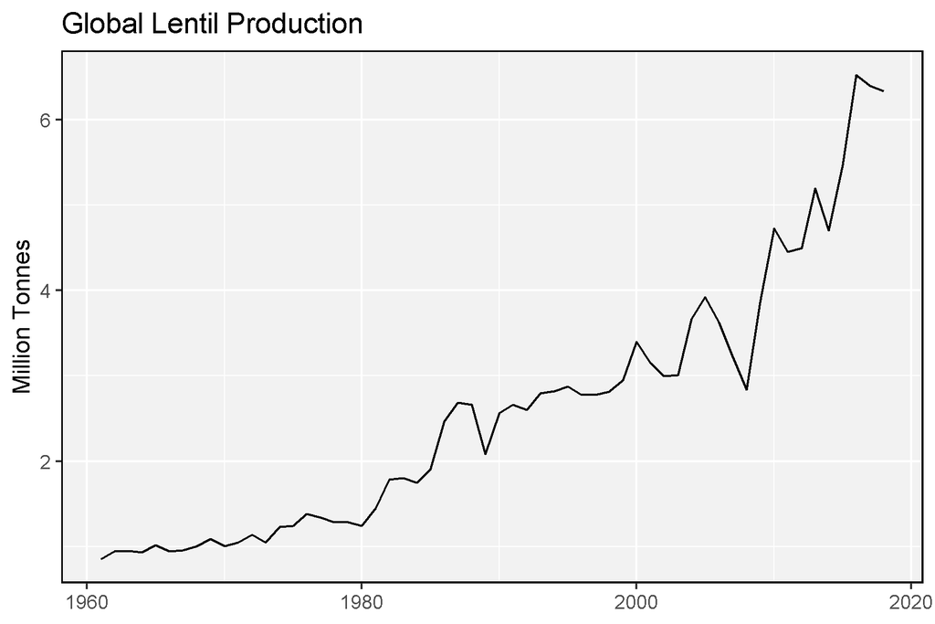

```r
# Prep data for an example plot
xx <- xx %>% filter(Area == "World", Crop == "Lentils", Measurement == "Production")
# Plot
mp <- ggplot(xx, aes(x = Year, y = Value / 1000000, group = Area)) +
  geom_line() +
  theme_agData() +
  labs(title = "Global Lentil Production",
       y = "Million Tonnes", x = NULL)
ggsave("Intro_agData_FAO_Crops.png", mp, width = 6, height = 4)
```

# agData_FAO_Crops2

```r
# Get Data
xx <- agData_FAO_Crops2 %>% as_tibble()
xx
```

```
## # A tibble: 623,051 x 6
##    Area         Year Crop             Measurement    Unit        Value
##    <fct>       <dbl> <chr>            <fct>          <chr>       <dbl>
##  1 Colombia     1961 Agave fibres nes Area harvested hectares 13500
##  2 Colombia     1961 Agave fibres nes Yield          t/ha         1.26
##  3 Colombia     1961 Agave fibres nes Production     tonnes   17000
##  4 Cuba         1961 Agave fibres nes Area harvested hectares 10000
##  5 Cuba         1961 Agave fibres nes Yield          t/ha         1.11
##  6 Cuba         1961 Agave fibres nes Production     tonnes   11100
##  7 El Salvador  1961 Agave fibres nes Area harvested hectares  5000
##  8 El Salvador  1961 Agave fibres nes Yield          t/ha         0.68
##  9 El Salvador  1961 Agave fibres nes Production     tonnes    3400
## 10 Guatemala    1961 Agave fibres nes Area harvested hectares   500
## # ... with 623,041 more rows
```

```r
# List Measurements
xx %>% distinct(Measurement, Unit)
```

```
## # A tibble: 3 x 2
##   Measurement    Unit
##   <fct>          <chr>
## 1 Area harvested hectares
## 2 Yield          t/ha
## 3 Production     tonnes
```

```r
# List Crops
xx %>% distinct(Crop)
```

```
## # A tibble: 32 x 1
##    Crop
##    <chr>
##  1 Agave fibres nes
##  2 Bastfibres, other
##  3 Berries nes
##  4 Cereals (Rice Milled Eqv)
##  5 Cereals nes
##  6 Cereals
##  7 Citrus Fruit
##  8 Coarse Grain
##  9 Fibre crops nes
## 10 Fibre Crops Primary
## # ... with 22 more rows
```

```r
# Spread data to wide format
xx %>% select(-Unit) %>% spread(Measurement, Value) %>% arrange(Year)
```

```
## # A tibble: 231,045 x 6
##    Area         Year Crop                      `Area harvested` Production Yield
##    <fct>       <dbl> <chr>                                <dbl>      <dbl> <dbl>
##  1 Afghanistan  1961 Berries nes                           6800      60000 8.82
##  2 Afghanistan  1961 Cereals                            3313500    3695000 1.12
##  3 Afghanistan  1961 Cereals (Rice Milled Eqv)          3313500    3588773 1.08
##  4 Afghanistan  1961 Citrus Fruit                          2160      15000 6.94
##  5 Afghanistan  1961 Coarse Grain                        873500    1097000 1.26
##  6 Afghanistan  1961 Fibre Crops Primary                  76892      17000 0.221
##  7 Afghanistan  1961 Fruit Primary                       108699     567200 5.22
##  8 Afghanistan  1961 Fruit, citrus nes                      730       4900 6.71
##  9 Afghanistan  1961 Fruit, fresh nes                     13919      71200 5.12
## 10 Afghanistan  1961 Fruit, stone nes                      2850      18100 6.35
## # ... with 231,035 more rows
```

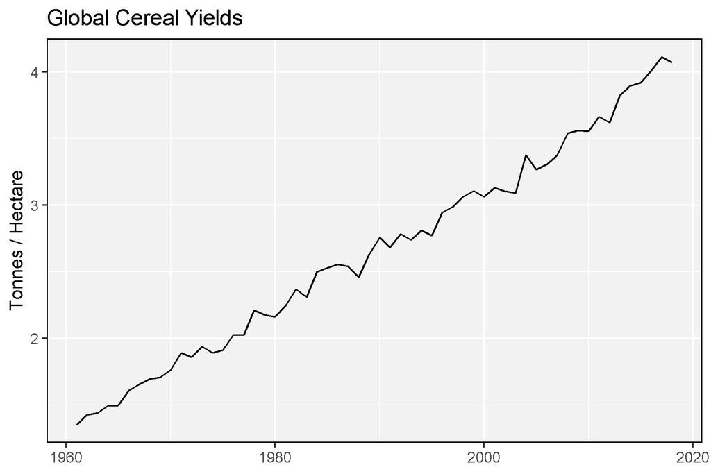

```r
# Prep data for an example plot
xx <- xx %>% filter(Area == "World", Crop == "Cereals", Measurement == "Yield")
# Plot
mp <- ggplot(xx, aes(x = Year, y = Value, group = Area)) +
  geom_line() +
  theme_agData() +
  labs(title = "Global Cereal Yields",
       y = "Tonnes / Hectare", x = NULL)
ggsave("Intro_agData_FAO_Crops2.png", mp, width = 6, height = 4)
```

# agData_FAO_Fertilizers

```r
# Get Data
xx <- agData_FAO_Fertilizers %>% as_tibble()
xx
```

```
## # A tibble: 438,316 x 6
##    Area         Year Item                    Measurement      Unit   Value
##    <fct>       <dbl> <chr>                   <chr>            <chr>  <dbl>
##  1 Afghanistan  1961 Nitrogenous fertilizers Import Quantity  tonnes  1000
##  2 Afghanistan  1961 Nitrogenous fertilizers Agricultural Use tonnes  1000
##  3 Afghanistan  1961 Phosphate fertilizers   Import Quantity  tonnes   100
##  4 Afghanistan  1961 Phosphate fertilizers   Agricultural Use tonnes   100
##  5 Afghanistan  1961 Total Fertilizers       Import Quantity  tonnes  1100
##  6 Afghanistan  1961 Total Fertilizers       Agricultural Use tonnes  1100
##  7 Albania      1961 Ammonium nitrate (AN)   Import Quantity  tonnes  3187
##  8 Albania      1961 Ammonium nitrate (AN)   Agricultural Use tonnes  3187
##  9 Albania      1961 Nitrogenous fertilizers Import Quantity  tonnes  3187
## 10 Albania      1961 Nitrogenous fertilizers Agricultural Use tonnes  3187
## # ... with 438,306 more rows
```

```r
# List Measurements
xx %>% distinct(Measurement, Unit)
```

```
## # A tibble: 6 x 2
##   Measurement      Unit
##   <chr>            <chr>
## 1 Import Quantity  tonnes
## 2 Agricultural Use tonnes
## 3 Production       tonnes
## 4 Export Quantity  tonnes
## 5 Import Value     1000 US$
## 6 Export Value     1000 US$
```

```r
# List Crops
xx %>% distinct(Item)
```

```
## # A tibble: 50 x 1
##    Item
##    <chr>
##  1 Nitrogenous fertilizers
##  2 Phosphate fertilizers
##  3 Total Fertilizers
##  4 Ammonium nitrate (AN)
##  5 Potash fertilizers
##  6 Single Superphosphate
##  7 Ammonium Phosphate (N)
##  8 Ammonium sulphate
##  9 Ammonium SulphateNitrate
## 10 Basic Slag
## # ... with 40 more rows
```

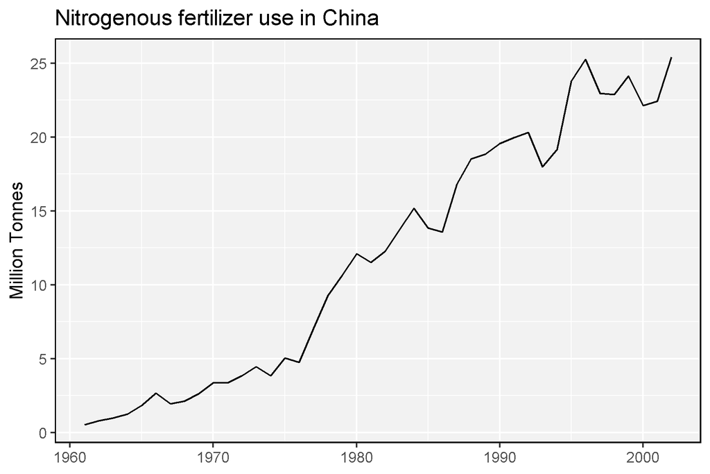

```r
# Prep data for an example plot
xx <- xx %>% filter(Area == "China",
                    Item == "Nitrogenous fertilizers",
                    Measurement == "Agricultural Use")
# Plot
mp <- ggplot(xx, aes(x = Year, y = Value / 1000000, group = Measurement)) +
  geom_line() +
  theme_agData() +
  labs(title = "Nitrogenous fertilizer use in China",
       y = "Million Tonnes", x = NULL)
ggsave("Intro_agData_FAO_Fertilizers.png", mp, width = 6, height = 4)
```

# agData_FAO_LandUse

```r
# Get Data
xx <- agData_FAO_LandUse %>% as_tibble()
xx
```

```
## # A tibble: 187,464 x 6
##    Area         Year Item                                  Measurement Unit          Value
##    <fct>       <dbl> <chr>                                 <chr>       <chr>         <dbl>
##  1 Afghanistan  1961 Country area                          Area        1000 hectares 65286
##  2 Afghanistan  1961 Land area                             Area        1000 hectares 65286
##  3 Afghanistan  1961 Agriculture                           Area        1000 hectares 37700
##  4 Afghanistan  1961 Agricultural land                     Area        1000 hectares 37700
##  5 Afghanistan  1961 Cropland                              Area        1000 hectares  7700
##  6 Afghanistan  1961 Arable land                           Area        1000 hectares  7650
##  7 Afghanistan  1961 Land under permanent crops            Area        1000 hectares    50
##  8 Afghanistan  1961 Land under perm. meadows and pastures Area        1000 hectares 30000
##  9 Afghanistan  1961 Land area equipped for irrigation     Area        1000 hectares  2380
## 10 Albania      1961 Country area                          Area        1000 hectares  2875
## # ... with 187,454 more rows
```

```r
# List Measurements
xx %>% distinct(Measurement, Unit)
```

```
## # A tibble: 2 x 2
##   Measurement                    Unit
##   <chr>                          <chr>
## 1 Area                           1000 hectares
## 2 Carbon stock in living biomass million tonnes
```

```r
# List Crops
xx %>% distinct(Item)
```

```
## # A tibble: 45 x 1
##    Item
##    <chr>
##  1 Country area
##  2 Land area
##  3 Agriculture
##  4 Agricultural land
##  5 Cropland
##  6 Arable land
##  7 Land under permanent crops
##  8 Land under perm. meadows and pastures
##  9 Land area equipped for irrigation
## 10 Inland waters
## # ... with 35 more rows
```

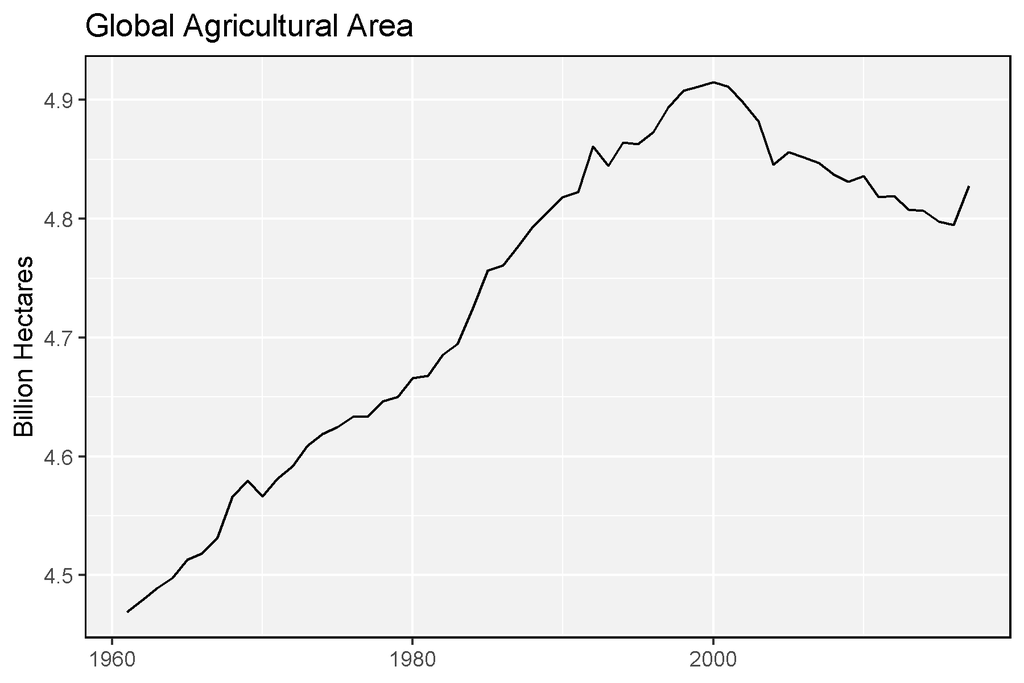

```r
# Prep data for an example plot
xx <- xx %>% filter(Area == "World", Item == "Agricultural land")
# Plot
mp <- ggplot(xx, aes(x = Year, y = Value / 1000000, group = Area)) +
  geom_line() +
  theme_agData() +
  labs(title = "Global Agricultural Area",
       y = "Billion Hectares", x = NULL)
ggsave("Intro_agData_FAO_LandUse.png", mp, width = 6, height = 4)
```

# agData_FAO_Livestock

```r
# Get Data
xx <- agData_FAO_Livestock %>% as_tibble()
xx
```

```
## # A tibble: 1,419,110 x 6
##    Area         Year Animal               Measurement Unit      Value
##    <fct>       <dbl> <chr>                <chr>       <chr>     <dbl>
##  1 Afghanistan  1961 Asses                Stocks      number  1300000
##  2 Afghanistan  1961 Camels               Stocks      number   250000
##  3 Afghanistan  1961 Cattle               Stocks      number  2900000
##  4 Afghanistan  1961 Chickens             Stocks      number  4700000
##  5 Afghanistan  1961 Goats                Stocks      number  4200000
##  6 Afghanistan  1961 Horses               Stocks      number   276841
##  7 Afghanistan  1961 Mules                Stocks      number    20000
##  8 Afghanistan  1961 Sheep                Stocks      number 18000000
##  9 Afghanistan  1961 Cattle and Buffaloes Stocks      number  2900000
## 10 Afghanistan  1961 Poultry Birds        Stocks      number  4700000
## # ... with 1,419,100 more rows
```

```r
# List Measurements
xx %>% distinct(Measurement, Unit)
```

```
## # A tibble: 13 x 2
##    Measurement                   Unit
##    <chr>                         <chr>
##  1 Stocks                        number
##  2 Laying                        number
##  3 Yield                         100mg/An
##  4 Production                    tonnes
##  5 Production                    1000 No
##  6 Producing Animals/Slaughtered number
##  7 Yield                         hg/An
##  8 Production                    number
##  9 Yield/Carcass Weight          hg/An
## 10 Yield/Carcass Weight          0.1g/An
## 11 Milk Animals                  number
## 12 Prod Popultn                  number
## 13 Yield                         hg
```

```r
# List Crops
xx %>% distinct(Animal)
```

```
## # A tibble: 97 x 1
##    Animal
##    <chr>
##  1 Asses
##  2 Camels
##  3 Cattle
##  4 Chickens
##  5 Goats
##  6 Horses
##  7 Mules
##  8 Sheep
##  9 Cattle and Buffaloes
## 10 Poultry Birds
## # ... with 87 more rows
```

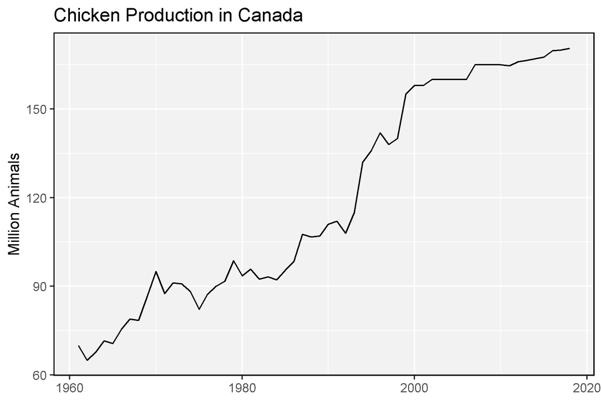

```r
# Prep data for an example plot
xx <- xx %>% filter(Area == "Canada", Animal == "Chickens")
# Plot
mp <- ggplot(xx, aes(x = Year, y = Value / 1000000, group = Area)) +
  geom_line() +
  theme_agData() +
  labs(title = "Chicken Production in Canada",
       y = "Million Animals", x = NULL)
ggsave("Intro_agData_FAO_Livestock.png", mp, width = 6, height = 4)
```

# agData_FAO_Population

```r
# Get Data
xx <- agData_FAO_Population %>% as_tibble()
# List Measurements
xx %>% distinct(Measurement, Unit)
```

```
## # A tibble: 5 x 2
##   Measurement Unit
##   <chr>       <chr>
## 1 Total       People
## 2 Male        People
## 3 Female      People
## 4 Rural       People
## 5 Urban       People
```

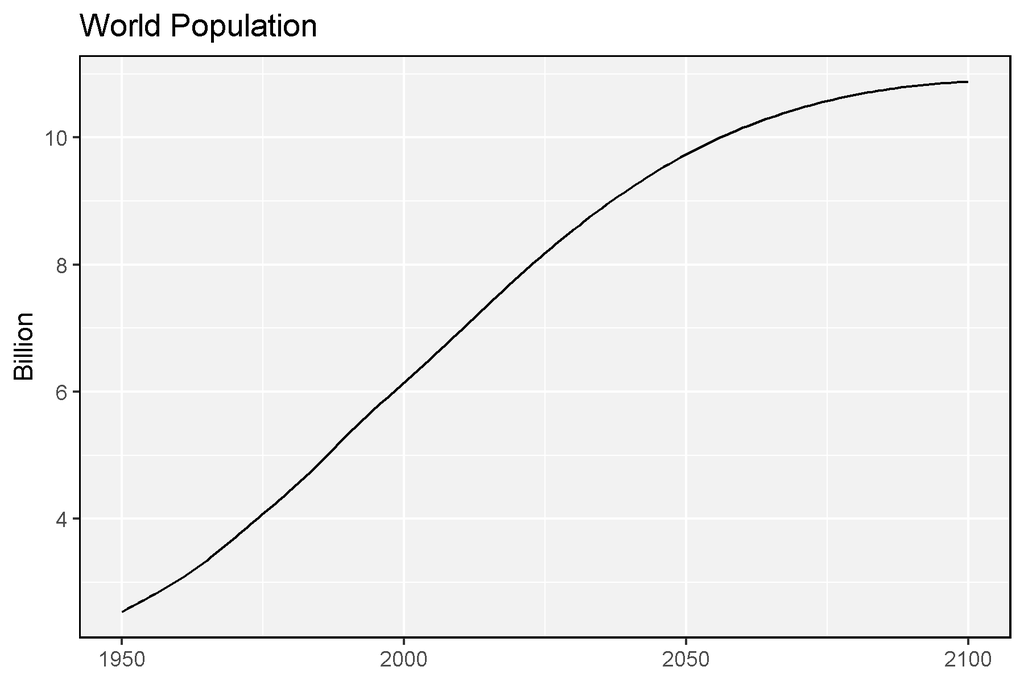

```r
# Prep data for an example plot
xx <- xx %>% filter(Area == "World", Measurement == "Total")
# Plot
mp <- ggplot(xx, aes(x = Year, y = Value / 1000000000, group = Measurement)) +
  geom_line() +
  theme_agData() +
  labs(title = "World Population",
       y = "Billion", x = NULL)
ggsave("Intro_agData_FAO_Population.png", mp, width = 6, height = 4)
```

# agData_FAO_Trade

```r
# Get Data
xx <- agData_FAO_Trade %>% as_tibble()
xx
```

```
## # A tibble: 9,255,812 x 6
##    Area         Year Crop                   Measurement     Unit     Value
##    <fct>       <dbl> <chr>                  <chr>           <chr>    <dbl>
##  1 Afghanistan  1961 Butter, cow milk       Import Quantity tonnes      23
##  2 Afghanistan  1961 Butter, cow milk       Import Value    USD      16000
##  3 Afghanistan  1961 Cheese, whole cow milk Import Quantity tonnes       3
##  4 Afghanistan  1961 Cheese, whole cow milk Import Value    USD       2000
##  5 Afghanistan  1961 Cigarettes             Import Quantity tonnes     150
##  6 Afghanistan  1961 Cigarettes             Import Value    USD     526000
##  7 Afghanistan  1961 Cotton lint            Export Quantity tonnes   11480
##  8 Afghanistan  1961 Cotton lint            Export Value    USD    8320000
##  9 Afghanistan  1961 Cottonseed             Export Quantity tonnes    3050
## 10 Afghanistan  1961 Cottonseed             Export Value    USD     227000
## # ... with 9,255,802 more rows
```

```r
# List Measurements
xx %>% distinct(Measurement, Unit)
```

```
## # A tibble: 4 x 2
##   Measurement     Unit
##   <chr>           <chr>
## 1 Import Quantity tonnes
## 2 Import Value    USD
## 3 Export Quantity tonnes
## 4 Export Value    USD
```

```r
# List Crops
xx %>% distinct(Crop)
```

```
## # A tibble: 469 x 1
##    Crop
##    <chr>
##  1 Butter, cow milk
##  2 Cheese, whole cow milk
##  3 Cigarettes
##  4 Cotton lint
##  5 Cottonseed
##  6 Fruit, fresh nes
##  7 Grapes
##  8 Hides, cattle, wet salted
##  9 Linseed
## 10 Milk, skimmed dried
## # ... with 459 more rows
```

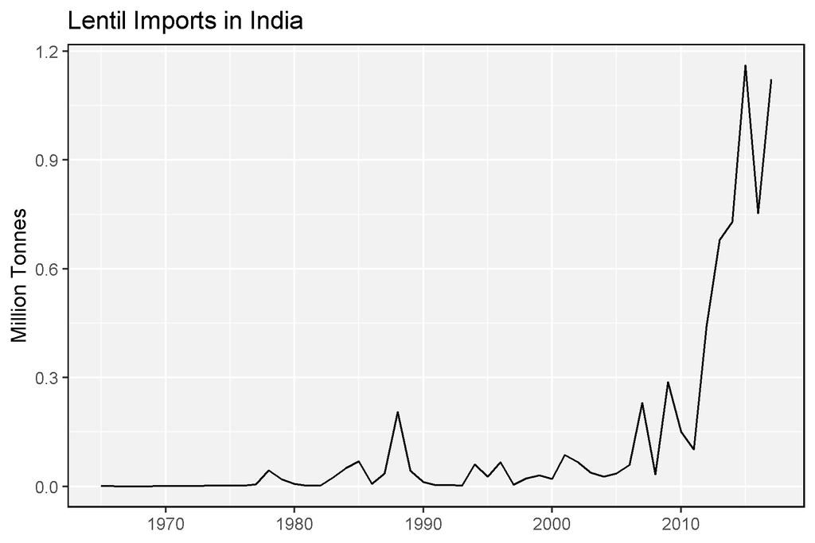

```r
# Prep data for an example plot
xx <- xx %>% filter(Area == "India", Crop == "Lentils", Measurement == "Import Quantity")
# Plot
mp <- ggplot(xx, aes(x = Year, y = Value / 1000000, group = Measurement)) +
  geom_line() +
  theme_agData() +
  labs(title = "Lentil Imports in India",
       y = "Million Tonnes", x = NULL)
ggsave("Intro_agData_FAO_Trade.png", mp, width = 6, height = 4)
```

# agData_STATCAN_Region_Table

```r
DT::datatable(agData_STATCAN_Region_Table)
```

|  | Area | Area_Short | Lat | Lon |
| --- | --- | --- | --- | --- |
| 1 | Canada | CA | 54.27 | -101.79 |
| 2 | British Columbia | BC | 51.66 | -121.5 |
| 3 | Alberta | AB | 53.4 | -113.51 |
| 4 | Saskatchewan | SK | 51.52 | -105.7 |
| 5 | Manitoba | MB | 50.2 | -99 |
| 6 | Ontario | ON | 48.25 | -82.64 |
| 7 | Quebec | QC | 48.22 | -72.9 |
| 8 | New Brunswick | NB | 46.7 | -66.15 |
| 9 | Prince Edward Island | PE | 46.35 | -63.19 |
| 10 | Nova Scotia | NS | 44.56 | -64.71 |

[output cut: 4 more lines]

# agData_STATCAN_Beehives

```r
# Get Data
xx <- agData_STATCAN_Beehives %>% as_tibble()
xx
```

```
## # A tibble: 7,460 x 5
##    Area                  Year Measurement  Value Unit
##    <fct>                <int> <fct>        <dbl> <fct>
##  1 Alberta               1924 Beekeepers   0.16  Thousand
##  2 British Columbia      1924 Beekeepers   2.41  Thousand
##  3 Canada                1924 Beekeepers  22.2   Thousand
##  4 Manitoba              1924 Beekeepers   1.26  Thousand
##  5 New Brunswick         1924 Beekeepers   0.36  Thousand
##  6 Nova Scotia           1924 Beekeepers   0.2   Thousand
##  7 Ontario               1924 Beekeepers  10     Thousand
##  8 Prince Edward Island  1924 Beekeepers   0.005 Thousand
##  9 Quebec                1924 Beekeepers   7.4   Thousand
## 10 Saskatchewan          1924 Beekeepers   0.41  Thousand
## # ... with 7,450 more rows
```

```r
# List Measurements
xx %>% distinct(Measurement, Unit)
```

```
## # A tibble: 8 x 2
##   Measurement            Unit
##   <fct>                  <fct>
## 1 Beekeepers             Thousand
## 2 Colonies               Thousand
## 3 Production             Million kg
## 4 Value of honey and wax Million CAD
## 5 Value of honey         Million CAD
## 6 Colonies per beekeeper Number
## 7 Yield                  kg per colony
## 8 Value per colony       CAD per colony
```

```r
# Spread data to wide format
yy <- xx %>% select(-Unit) %>% spread(Measurement, Value) %>% arrange(Year)
str(yy)
```

```
## tibble [960 x 10] (S3: tbl_df/tbl/data.frame)
##  $ Area                  : Factor w/ 10 levels "Canada","British Columbia",..: 1 2 3 4 5 6 7 8 9 10 ...
##  $ Year                  : int [1:960] 1924 1924 1924 1924 1924 1924 1924 1924 1924 1924 ...
##  $ Beekeepers            : num [1:960] 22.2 2.41 0.16 0.41 1.26 ...
##  $ Colonies              : num [1:960] 280 14.6 0 1.2 10.8 ...
##  $ Colonies per beekeeper: num [1:960] 13 6 0 3 9 16 12 6 6 18 ...
##  $ Production            : num [1:960] 16.84 0.679 0.055 0.079 0.651 ...
##  $ Yield                 : num [1:960] 27.3 21.1 Inf 29.9 27.2 ...
##  $ Value per colony      : num [1:960] 7.45 10.21 Inf 15 9.04 ...
##  $ Value of honey        : num [1:960] 2.085 0.149 0.014 0.018 0.098 ...
##  $ Value of honey and wax: num [1:960] 2.183 0.156 0.014 0.019 0.102 ...
```

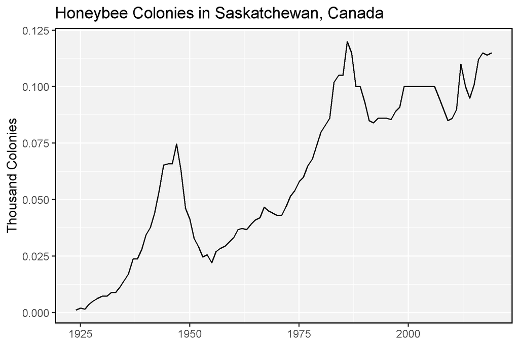

```r
# Prep data for an example plot
xx <- xx %>% filter(Area == "Saskatchewan", Measurement == "Colonies")
# Plot
mp <- ggplot(xx, aes(x = Year, y = Value / 1000, group = Area)) +
  geom_line() +
  theme_agData() +
  labs(title = "Honeybee Colonies in Saskatchewan, Canada",
       y = "Thousand Colonies", x = NULL)
ggsave("Intro_agData_STATCAN_Beehives.png", mp, width = 6, height = 4)
```

# agData_STATCAN_Crops

```r
# Get Data
xx <- agData_STATCAN_Crops %>% as_tibble()
xx
```

```
## # A tibble: 58,105 x 6
##    Area                  Year Crop   Measurement Unit     Value
##    <fct>                <int> <chr>  <fct>       <chr>    <dbl>
##  1 Canada                1908 Barley Seeded area ha      707100
##  2 Canada                1908 Barley Yield       kg/ha     1440
##  3 Canada                1908 Barley Production  tonnes 1016850
##  4 Maritime provinces    1908 Barley Seeded area ha        7700
##  5 Maritime provinces    1908 Barley Yield       kg/ha     1525
##  6 Maritime provinces    1908 Barley Production  tonnes   11750
##  7 Prince Edward Island  1908 Barley Seeded area ha        2400
##  8 Prince Edward Island  1908 Barley Yield       kg/ha     1665
##  9 Prince Edward Island  1908 Barley Production  tonnes    4000
## 10 Nova Scotia           1908 Barley Seeded area ha        3900
## # ... with 58,095 more rows
```

```r
# List Measurements
xx %>% distinct(Measurement, Unit)
```

```
## # A tibble: 5 x 2
##   Measurement        Unit
##   <fct>              <chr>
## 1 Seeded area        ha
## 2 Yield              kg/ha
## 3 Production         tonnes
## 4 Harvested area     ha
## 5 Average farm price dollars per tonne
```

```r
# List Crops
xx %>% distinct(Crop)
```

```
## # A tibble: 28 x 1
##    Crop
##    <chr>
##  1 Barley
##  2 Beans
##  3 Borage seed
##  4 Buckwheat
##  5 Canary seed
##  6 Canola
##  7 Caraway seed
##  8 Chick peas
##  9 Coriander seed
## 10 Corn for grain
## # ... with 18 more rows
```

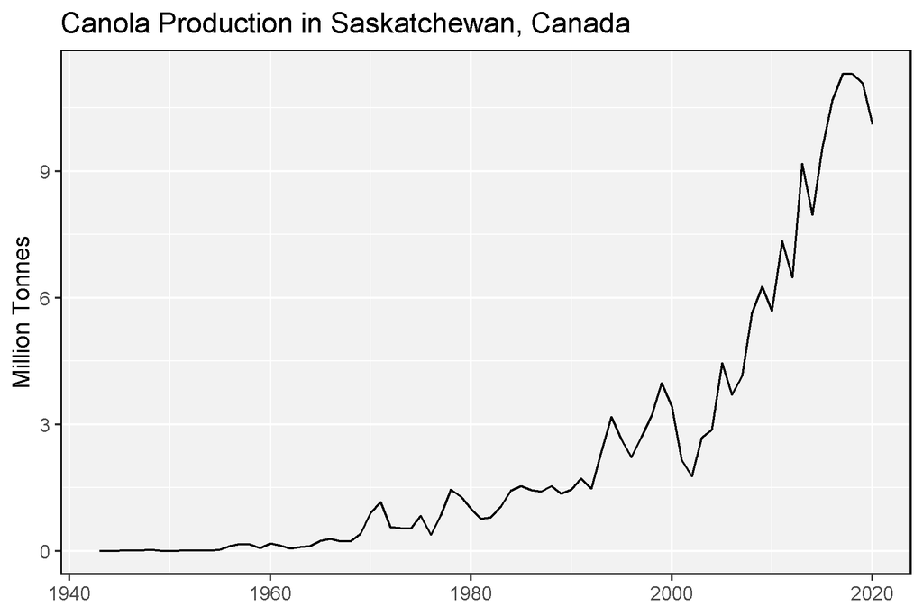

```r
# Prep data for an example plot
xx <- xx %>% filter(Area == "Saskatchewan", Crop == "Canola", Measurement == "Production")
# Plot
mp <- ggplot(xx, aes(x = Year, y = Value / 1000000, group = Area)) +
  geom_line() +
  theme_agData() +
  labs(title = "Canola Production in Saskatchewan, Canada",
       y = "Million Tonnes", x = NULL)
ggsave("Intro_agData_STATCAN_Crops.png", mp, width = 6, height = 4)
```

# agData_STATCAN_FarmLand_Crops

```r
# Get Data
xx <- agData_STATCAN_FarmLand_Crops %>% as_tibble()
xx
```

```
## # A tibble: 6,442 x 6
##    Area    Year Crop           Measurement               Unit       Value
##    <fct>  <int> <chr>          <chr>                     <chr>      <int>
##  1 Canada  1921 Total wheat    Number of farms reporting Number    381293
##  2 Canada  1921 Total wheat    Hectares                  Hectares 8205434
##  3 Canada  1921 Oats           Number of farms reporting Number    572034
##  4 Canada  1921 Oats           Hectares                  Hectares 5757969
##  5 Canada  1921 Barley         Number of farms reporting Number    217047
##  6 Canada  1921 Barley         Hectares                  Hectares  878971
##  7 Canada  1921 Corn for grain Hectares                  Hectares   93628
##  8 Canada  1921 Flaxseed       Hectares                  Hectares  187612
##  9 Canada  1921 Potatoes       Number of farms reporting Number    524272
## 10 Canada  1921 Potatoes       Hectares                  Hectares  224718
## # ... with 6,432 more rows
```

```r
# List Measurements
xx %>% distinct(Measurement, Unit)
```

```
## # A tibble: 2 x 2
##   Measurement               Unit
##   <chr>                     <chr>
## 1 Number of farms reporting Number
## 2 Hectares                  Hectares
```

```r
# List Crops
xx %>% distinct(Crop)
```

```
## # A tibble: 27 x 1
##    Crop
##    <chr>
##  1 Total wheat
##  2 Oats
##  3 Barley
##  4 Corn for grain
##  5 Flaxseed
##  6 Potatoes
##  7 Total tree fruits
##  8 Total vegetables (excluding greenhouse vegetables)
##  9 Spring wheat (excluding durum)
## 10 Durum wheat
## # ... with 17 more rows
```

[figure not shown]

```r
# Prep data for an example plot
xx <- xx %>%
  filter(Area == "Saskatchewan", Crop == "Total wheat",
         Measurement == "Number of farms reporting") %>%
  filter(!is.na(Value))
# Plot
mp <- ggplot(xx, aes(x = Year, y = Value, group = Area)) +
  geom_line() +
  theme_agData() +
  labs(title = "Number of Farms Growing Wheat in Saskatchewan, Canada",
       y = "Million Tonnes", x = NULL)
ggsave("Intro_agData_STATCAN_FarmLand_Crops.png", mp, width = 6, height = 4)
```

# agData_STATCAN_FarmLand_NoTill

```r
# Get Data
xx <- agData_STATCAN_FarmLand_NoTill %>% as_tibble()
xx
```

```
## # A tibble: 264 x 6
##    Area                       Year Item                                 Measurement               Unit        Value
##    <fct>                     <int> <chr>                                <chr>                     <chr>       <int>
##  1 Canada                     1991 Total land prepared for seeding      Number of farms reporting Number     210350
##  2 Canada                     1991 Total land prepared for seeding      Hectares                  Hectares 29028766
##  3 Canada                     1991 No-till seeding or zero-till seeding Number of farms reporting Number      17556
##  4 Canada                     1991 No-till seeding or zero-till seeding Hectares                  Hectares  1951154
##  5 Newfoundland and Labrador  1991 Total land prepared for seeding      Number of farms reporting Number        329
##  6 Newfoundland and Labrador  1991 Total land prepared for seeding      Hectares                  Hectares     2050
##  7 Newfoundland and Labrador  1991 No-till seeding or zero-till seeding Number of farms reporting Number         28
##  8 Newfoundland and Labrador  1991 No-till seeding or zero-till seeding Hectares                  Hectares      169
##  9 Prince Edward Island       1991 Total land prepared for seeding      Number of farms reporting Number       1867
## 10 Prince Edward Island       1991 Total land prepared for seeding      Hectares                  Hectares   111720
## # ... with 254 more rows
```

```r
# List Measurements
xx %>% distinct(Measurement, Unit)
```

```
## # A tibble: 2 x 2
##   Measurement               Unit
##   <chr>                     <chr>
## 1 Number of farms reporting Number
## 2 Hectares                  Hectares
```

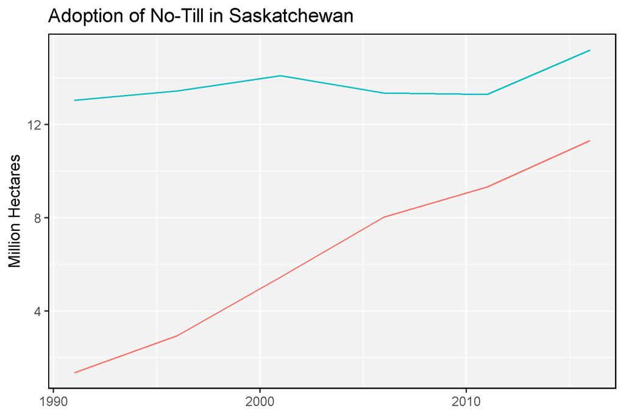

```r
# Prep data for an example plot
xx <- xx %>%
  filter(Area == "Saskatchewan",
         Unit == "Hectares") %>%
  filter(!is.na(Value))
# Plot
mp <- ggplot(xx, aes(x = Year, y = Value / 1000000, color = Item)) +
  geom_line() +
  theme_agData(legend.position = "none") +
  labs(title = "Adoption of No-Till in Saskatchewan",
       y = "Million Hectares", x = NULL)
ggsave("Intro_agData_STATCAN_FarmLand_Crops.png", mp, width = 6, height = 4)
```

# agData_STATCAN_FarmLand_Size

```r
# Get Data
xx <- agData_STATCAN_FarmLand_Size %>% as_tibble()
xx
```

```
## # A tibble: 1,485 x 5
##    Area    Year Measurement           Unit    Value
##    <fct>  <int> <fct>                 <chr>   <int>
##  1 Canada  1976 Total number of farms Number 338552
##  2 Canada  1976 Under 10 acres        Number  14095
##  3 Canada  1976 10 to 69 acres        Number  40573
##  4 Canada  1976 70 to 129 acres       Number  44010
##  5 Canada  1976 130 to 179 acres      Number  40693
##  6 Canada  1976 180 to 239 acres      Number  24262
##  7 Canada  1976 240 to 399 acres      Number  52859
##  8 Canada  1976 400 to 559 acres      Number  31571
##  9 Canada  1976 560 to 759 acres      Number  26616
## 10 Canada  1976 760 to 1,119 acres    Number  29513
## # ... with 1,475 more rows
```

```r
# List Measurements
xx %>% distinct(Measurement)
```

```
## # A tibble: 15 x 1
##    Measurement
##    <fct>
##  1 Total number of farms
##  2 Under 10 acres
##  3 10 to 69 acres
##  4 70 to 129 acres
##  5 130 to 179 acres
##  6 180 to 239 acres
##  7 240 to 399 acres
##  8 400 to 559 acres
##  9 560 to 759 acres
## 10 760 to 1,119 acres
## 11 1,120 to 1,599 acres
## 12 1,600 to 2,239 acres
## 13 2,240 to 2,879 acres
## 14 2,880 to 3,519 acres
## 15 3,520 acres and above
```

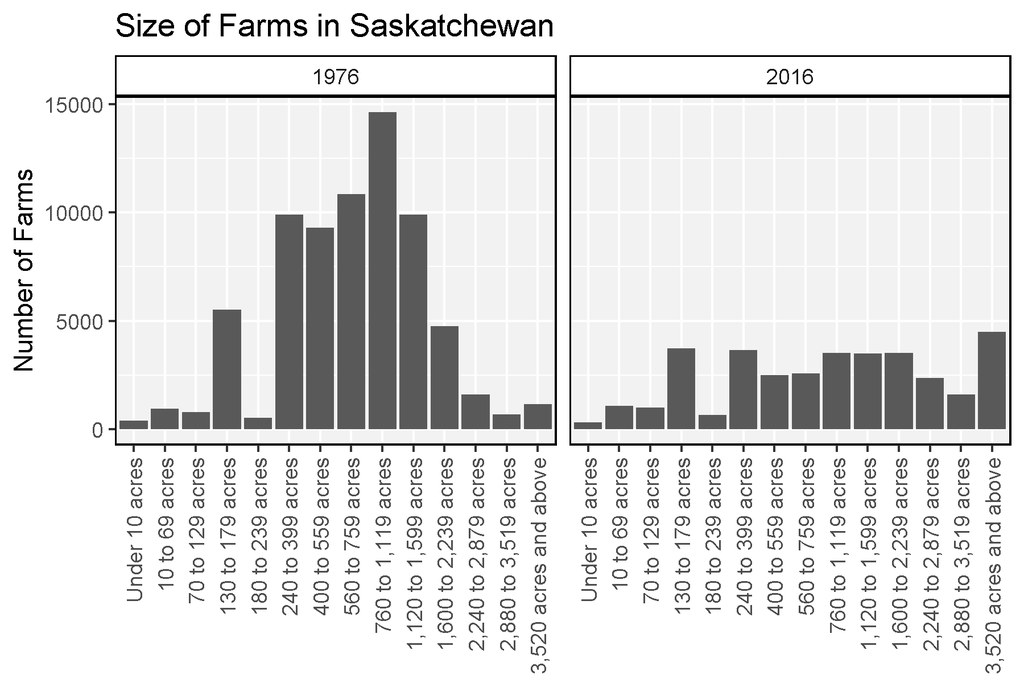

```r
# Prep data for an example plot
xx <- xx %>%
  filter(Area == "Saskatchewan", Year %in% c(1976, 2016),
         Measurement != "Total number of farms")
# Plot
mp <- ggplot(xx, aes(x = Measurement, y = Value, group = Area)) +
  geom_bar(stat = "identity") +
  facet_grid(. ~ Year) +
  theme_agData(axis.text.x = element_text(angle = 90, hjust = 1, vjust = 0.5)) +
  labs(title = "Size of Farms in Saskatchewan",
       y = "Number of Farms", x = NULL)
ggsave("Intro_agData_STATCAN_FarmLand_Size.png", mp, width = 6, height = 4)
```

# agData_STATCAN_FarmLand_Use

```r
# Get Data
xx <- agData_STATCAN_FarmLand_Use %>% as_tibble()
xx
```

```
## # A tibble: 1,289 x 6
##    Area                  Year Item                Measurement               Unit        Value
##    <fct>                <int> <chr>               <chr>                     <chr>       <int>
##  1 Canada                1921 Total area of farms Number of farms reporting Number     711090
##  2 Canada                1921 Total area of farms Hectares                  Hectares 57015306
##  3 Canada                1921 Land in crops       Hectares                  Hectares 20247882
##  4 Prince Edward Island  1921 Total area of farms Number of farms reporting Number      13701
##  5 Prince Edward Island  1921 Total area of farms Hectares                  Hectares   492293
##  6 Prince Edward Island  1921 Land in crops       Hectares                  Hectares   186690
##  7 Nova Scotia           1921 Total area of farms Number of farms reporting Number      47432
##  8 Nova Scotia           1921 Total area of farms Hectares                  Hectares  1911553
##  9 Nova Scotia           1921 Land in crops       Hectares                  Hectares   278448
## 10 New Brunswick         1921 Total area of farms Number of farms reporting Number      36655
## # ... with 1,279 more rows
```

```r
# List Measurements
xx %>% distinct(Measurement, Unit)
```

```
## # A tibble: 2 x 2
##   Measurement               Unit
##   <chr>                     <chr>
## 1 Number of farms reporting Number
## 2 Hectares                  Hectares
```

```r
# List Items
xx %>% distinct(Item)
```

```
## # A tibble: 5 x 1
##   Item
##   <chr>
## 1 Total area of farms
## 2 Land in crops
## 3 Summerfallow land
## 4 Tame or seeded pasture
## 5 All other land
```

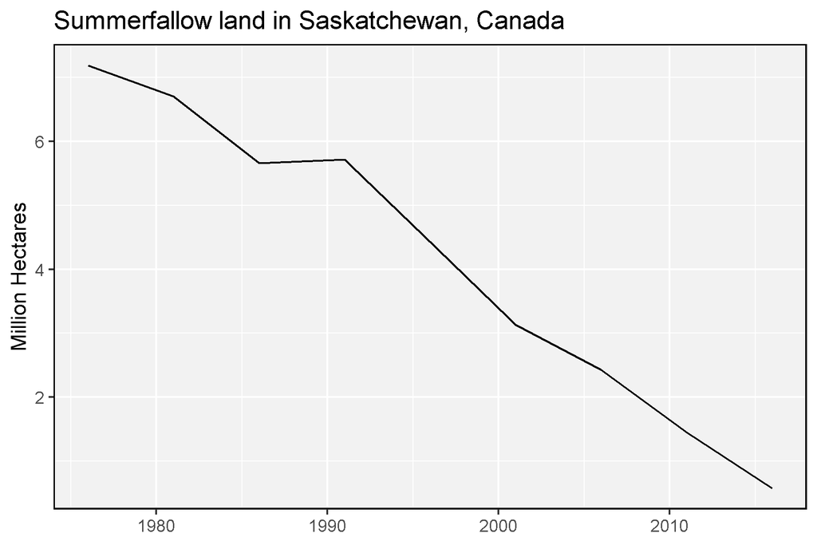

```r
# Prep data for an example plot
xx <- xx %>% filter(Area == "Saskatchewan", Item == "Summerfallow land", Unit == "Hectares")
# Plot
mp <- ggplot(xx, aes(x = Year, y = Value / 1000000, group = Area)) +
  geom_line() +
  theme_agData() +
  labs(title = "Summerfallow land in Saskatchewan, Canada",
       y = "Million Hectares", x = NULL)
ggsave("Intro_agData_STATCAN_FarmLand_Use.png", mp, width = 6, height = 4)
```

# agData_STATCAN_Livestock

```r
# Get Data
xx <- agData_STATCAN_Livestock %>% as_tibble()
xx
```

```
## # A tibble: 7,545 x 6
##    Area    Year Animal                  Measurement               Unit     Value
##    <fct>  <int> <chr>                   <chr>                     <chr>    <int>
##  1 Canada  1921 Total cattle and calves Number of animals         Number 8369489
##  2 Canada  1921 Total pigs              Number of farms reporting Number  452935
##  3 Canada  1921 Total pigs              Number of animals         Number 3324291
##  4 Canada  1921 Total pigs              Average number of animals Number       7
##  5 Canada  1921 Total sheep and lambs   Number of farms reporting Number  161838
##  6 Canada  1921 Total sheep and lambs   Number of animals         Number 3200467
##  7 Canada  1921 Total sheep and lambs   Average number of animals Number      20
##  8 Canada  1921 Horses and ponies       Number of farms reporting Number  608272
##  9 Canada  1921 Horses and ponies       Number of animals         Number 3451752
## 10 Canada  1921 Horses and ponies       Average number of animals Number       6
## # ... with 7,535 more rows
```

```r
# List Measurements
xx %>% distinct(Measurement, Unit)
```

```
## # A tibble: 3 x 2
##   Measurement               Unit
##   <chr>                     <chr>
## 1 Number of animals         Number
## 2 Number of farms reporting Number
## 3 Average number of animals Number
```

```r
# List Crops
xx %>% distinct(Animal)
```

```
## # A tibble: 26 x 1
##    Animal
##    <chr>
##  1 Total cattle and calves
##  2 Total pigs
##  3 Total sheep and lambs
##  4 Horses and ponies
##  5 Total hens and chickens (birds)
##  6 Dairy cows
##  7 Beef cows
##  8 Total heifers
##  9 Bulls, 1 year and over
## 10 Steers, 1 year and over
## # ... with 16 more rows
```

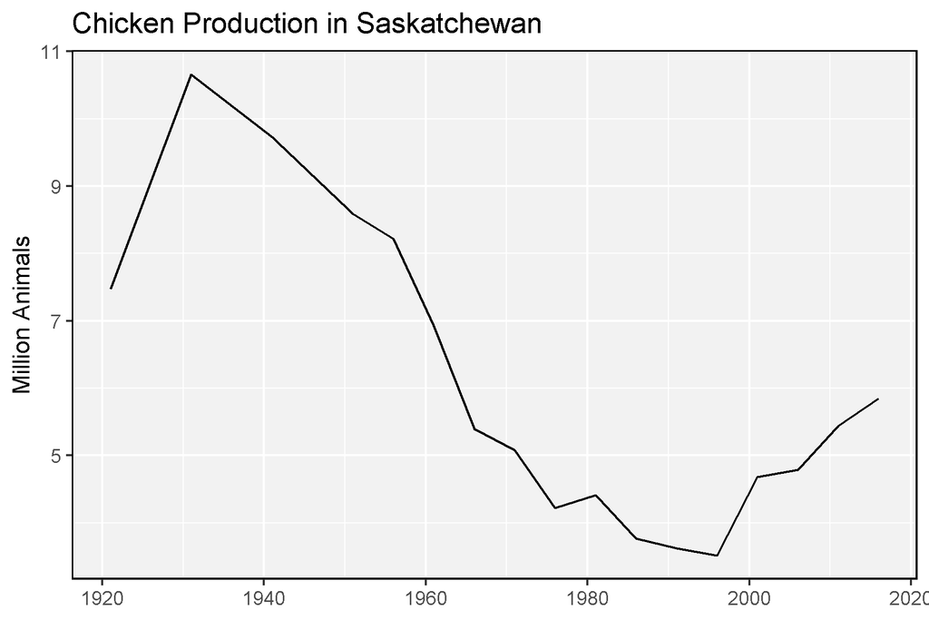

```r
# Prep data for an example plot
xx <- xx %>% filter(Area == "Saskatchewan",
                    Measurement == "Number of animals",
                    Animal == "Total hens and chickens (birds)")
# Plot
mp <- ggplot(xx, aes(x = Year, y = Value / 1000000)) +
  geom_line() +
  theme_agData() +
  labs(title = "Chicken Production in Saskatchewan",
       y = "Million Animals", x = NULL)
ggsave("Intro_agData_STATCAN_Livestock.png", mp, width = 6, height = 4)
```

# agData_STATCAN_Population

```r
# Get Data
xx <- agData_STATCAN_Population %>% as_tibble()
xx
```

```
## # A tibble: 3,580 x 5
##    Area    Year Month Unit       Value
##    <fct>  <dbl> <dbl> <chr>      <int>
##  1 Canada  1946     1 Persons 12188000
##  2 Canada  1946     4 Persons 12241000
##  3 Canada  1946     7 Persons 12316000
##  4 Canada  1946    10 Persons 12393000
##  5 Canada  1947     1 Persons 12450000
##  6 Canada  1947     4 Persons 12507000
##  7 Canada  1947     7 Persons 12576000
##  8 Canada  1947    10 Persons 12646000
##  9 Canada  1948     1 Persons 12710000
## 10 Canada  1948     4 Persons 12773000
## # ... with 3,570 more rows
```

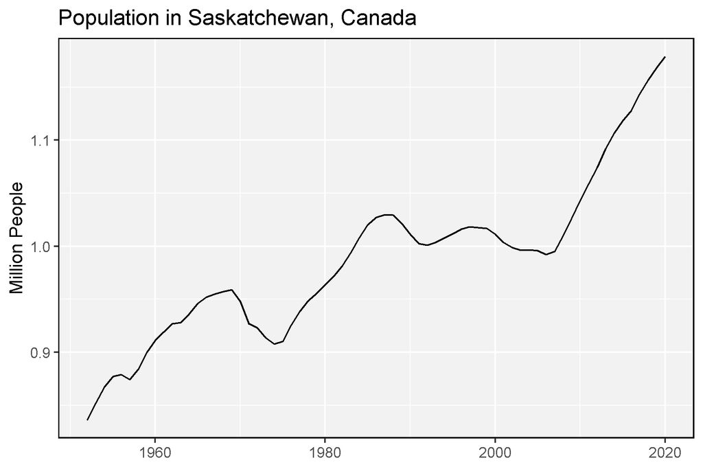

```r
# Prep data for an example plot
xx <- xx %>% filter(Area == "Saskatchewan", Month == 1)
# Plot
mp <- ggplot(xx, aes(x = Year, y = Value / 1000000)) +
  geom_line() +
  theme_agData() +
  labs(title = "Population in Saskatchewan, Canada",
       y = "Million People", x = NULL)
ggsave("Intro_agData_agData_STATCAN_Population.png", mp, width = 6, height = 4)
```

# agData_USDA_Crops

```r
# Get Data
xx <- agData_USDA_Crops %>% as_tibble()
xx
```

```
## # A tibble: 2,555 x 6
##    Area   Year Crop   Measurement    Unit           Value
##    <fct> <dbl> <fct>  <fct>          <fct>          <dbl>
##  1 USA    1866 Wheat  Area harvested hectares  6235402.
##  2 USA    1866 Wheat  Yield          t/ha            0.74
##  3 USA    1866 Wheat  Production     tonnes    4618555.
##  4 USA    1866 Maize  Area harvested hectares 12147460.
##  5 USA    1866 Maize  Yield          t/ha            1.52
##  6 USA    1866 Maize  Production     tonnes   18563517.
##  7 USA    1866 Barley Area harvested hectares   305133.
##  8 USA    1866 Barley Yield          t/ha            1.29
##  9 USA    1866 Barley Production     tonnes     393972.
## 10 USA    1866 Oats   Area harvested hectares  3211183.
## # ... with 2,545 more rows
```

```r
# List Measurements
xx %>% distinct(Measurement, Unit)
```

```
## # A tibble: 4 x 2
##   Measurement    Unit
##   <fct>          <fct>
## 1 Area harvested hectares
## 2 Yield          t/ha
## 3 Production     tonnes
## 4 Area seeded    hectares
```

```r
# List Area
xx %>% distinct(Area)
```

```
## # A tibble: 1 x 1
##   Area
##   <fct>
## 1 USA
```

```r
# List Crops
xx %>% distinct(Crop)
```

```
## # A tibble: 5 x 1
##   Crop
##   <fct>
## 1 Wheat
## 2 Maize
## 3 Barley
## 4 Oats
## 5 Sorghum
```

```r
# Spread data to wide format
xx %>% select(-Unit) %>% spread(Measurement, Value) %>% arrange(Year)
```

```
## # A tibble: 697 x 7
##    Area   Year Crop   `Area harvested` `Area seeded` Production Yield
##    <fct> <dbl> <fct>             <dbl>         <dbl>      <dbl> <dbl>
##  1 USA    1866 Barley          305133.            NA    393972. 1.29
##  2 USA    1866 Maize         12147460.            NA  18563517. 1.52
##  3 USA    1866 Oats           3211183.            NA   3583486. 1.12
##  4 USA    1866 Wheat          6235402.            NA   4618555. 0.74
##  5 USA    1867 Barley          428158.            NA    519272. 1.21
##  6 USA    1867 Maize         12996896.            NA  20166102. 1.55
##  7 USA    1867 Oats           3308713.            NA   3433043. 1.04
##  8 USA    1867 Wheat          6773634.            NA   5739154. 0.847
##  9 USA    1868 Barley          430586.            NA    505120. 1.17
## 10 USA    1868 Maize         14210954.            NA  23358645. 1.64
## # ... with 687 more rows
```

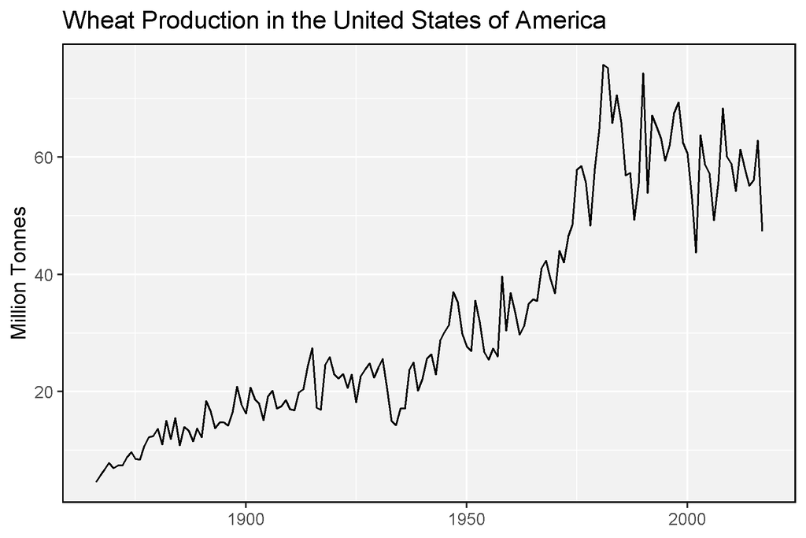

```r
# Prep data for an example plot
xx <- xx %>% filter(Crop == "Wheat", Measurement == "Production")
# Plot
mp <- ggplot(xx, aes(x = Year, y = Value / 1000000, group = Area)) +
  geom_line() +
  theme_agData() +
  labs(title = "Wheat Production in the United States of America",
       y = "Million Tonnes", x = NULL)
ggsave("Intro_agData_USDA_Crops.png", mp, width = 6, height = 4)
```

# agData_USDA_GE_Crops

```r
# Get Data
xx <- agData_USDA_GE_Crops %>% as_tibble()
xx
```

```
## # A tibble: 2,832 x 6
##    Area          Year Crop                                       Measurement                Unit                    Value
##    <chr>        <int> <chr>                                      <chr>                      <chr>                   <dbl>
##  1 Illinois      2000 Genetically engineered (GE) corn varieties Insect-resistant (Bt) only Percent of corn planted    13
##  2 Indiana       2000 Genetically engineered (GE) corn varieties Insect-resistant (Bt) only Percent of corn planted     7
##  3 Iowa          2000 Genetically engineered (GE) corn varieties Insect-resistant (Bt) only Percent of corn planted    23
##  4 Kansas        2000 Genetically engineered (GE) corn varieties Insect-resistant (Bt) only Percent of corn planted    25
##  5 Michigan      2000 Genetically engineered (GE) corn varieties Insect-resistant (Bt) only Percent of corn planted     8
##  6 Minnesota     2000 Genetically engineered (GE) corn varieties Insect-resistant (Bt) only Percent of corn planted    28
##  7 Missouri      2000 Genetically engineered (GE) corn varieties Insect-resistant (Bt) only Percent of corn planted    20
##  8 Nebraska      2000 Genetically engineered (GE) corn varieties Insect-resistant (Bt) only Percent of corn planted    24
##  9 Ohio          2000 Genetically engineered (GE) corn varieties Insect-resistant (Bt) only Percent of corn planted     6
## 10 South Dakota  2000 Genetically engineered (GE) corn varieties Insect-resistant (Bt) only Percent of corn planted    35
## # ... with 2,822 more rows
```

```r
# List Measurements
xx %>% distinct(Measurement, Unit)
```

```
## # A tibble: 10 x 2
##    Measurement                Unit
##    <chr>                      <chr>
##  1 Insect-resistant (Bt) only Percent of corn planted
##  2 Herbicide-tolerant only    Percent of corn planted
##  3 Stacked gene varieties     Percent of corn planted
##  4 All GE varieties           Percent of corn planted
##  5 Insect-resistant (Bt) only Percent of upland cotton planted
##  6 Herbicide-tolerant only    Percent of upland cotton planted
##  7 Stacked gene varieties     Percent of upland cotton planted
##  8 All GE varieties           Percent of upland cotton planted
##  9 Herbicide-tolerant only    Percent of all soybeans planted
## 10 All GE varieties           Percent of all soybeans planted
```

```r
# List Area
xx %>% distinct(Area)
```

```
## # A tibble: 23 x 1
##    Area
##    <chr>
##  1 Illinois
##  2 Indiana
##  3 Iowa
##  4 Kansas
##  5 Michigan
##  6 Minnesota
##  7 Missouri
##  8 Nebraska
##  9 Ohio
## 10 South Dakota
## # ... with 13 more rows
```

```r
# List Crops
xx %>% distinct(Crop)
```

```
## # A tibble: 3 x 1
##   Crop
##   <chr>
## 1 Genetically engineered (GE) corn varieties
## 2 Genetically engineered (GE) upland cotton varieties
## 3 Genetically engineered (GE) soybean varieties
```

```r
# Spread data to wide format
xx %>% select(-Unit) %>% spread(Measurement, Value) %>% arrange(Year)
```

```
## # A tibble: 878 x 7
##    Area       Year Crop                                  `All GE varieties` `Herbicide-tolerant o~ `Insect-resistant (Bt) ~ `Stacked gene variet~
##    <chr>     <int> <chr>                                              <dbl>                  <dbl>                    <dbl>                 <dbl>
##  1 Arkansas   2000 Genetically engineered (GE) soybean ~                 43                     43                       NA                    NA
##  2 Arkansas   2000 Genetically engineered (GE) upland c~                 70                     23                       33                    14
##  3 Californ~  2000 Genetically engineered (GE) upland c~                 24                     17                        3                     4
##  4 Georgia    2000 Genetically engineered (GE) upland c~                 82                     32                       18                    32
##  5 Illinois   2000 Genetically engineered (GE) corn var~                 17                      3                       13                     1
##  6 Illinois   2000 Genetically engineered (GE) soybean ~                 44                     44                       NA                    NA
##  7 Indiana    2000 Genetically engineered (GE) corn var~                 11                      4                        7                    NA
##  8 Indiana    2000 Genetically engineered (GE) soybean ~                 63                     63                       NA                    NA
##  9 Iowa       2000 Genetically engineered (GE) corn var~                 30                      5                       23                     2
## 10 Iowa       2000 Genetically engineered (GE) soybean ~                 59                     59                       NA                    NA
## # ... with 868 more rows
```

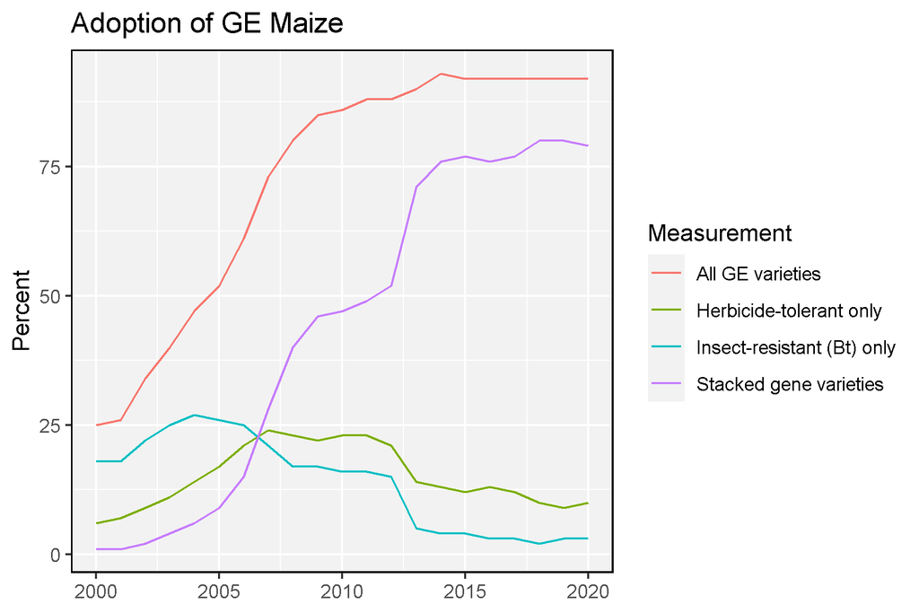

```r
# Prep data for an example plot
xx <- xx %>% filter(Crop == "Genetically engineered (GE) corn varieties",
                    Area == "U.S.")
# Plot
mp <- ggplot(xx, aes(x = Year, y = Value, color = Measurement)) +
  geom_line() +
  theme_agData() +
  labs(title = "Adoption of GE Maize",
       y = "Percent", x = NULL)
ggsave("Intro_agData_USDA_GE_Crops.png", mp, width = 6, height = 4)
```

# agData_USDA_TFP

```r
# Get Data
xx <- agData_USDA_TFP %>% as_tibble()
xx
```

```
## # A tibble: 120,602 x 4
##    Area                      Year Measurement Value
##    <chr>                    <dbl> <chr>       <dbl>
##  1 South Africa              1961 Ag TFP       52.9
##  2 Cameroon                  1961 Ag TFP       74.7
##  3 Central African Republic  1961 Ag TFP      100.
##  4 Congo, DR                 1961 Ag TFP      128.
##  5 Congo, Republic           1961 Ag TFP      117.
##  6 Equatorial Guinea         1961 Ag TFP      187.
##  7 Gabon                     1961 Ag TFP      127.
##  8 Sao Tome and Principe     1961 Ag TFP      125.
##  9 Burundi                   1961 Ag TFP      116.
## 10 Kenya                     1961 Ag TFP       66.7
## # ... with 120,592 more rows
```

```r
# List Measurements
xx %>% distinct(Measurement)
```

```
## # A tibble: 12 x 1
##    Measurement
##    <chr>
##  1 Ag TFP
##  2 Inputs
##  3 Output
##  4 Ag Land
##  5 Cropand
##  6 Irrig
##  7 Pasture
##  8 Labor
##  9 Livestock
## 10 Machinery
## 11 Fertilizer
## 12 Feed
```

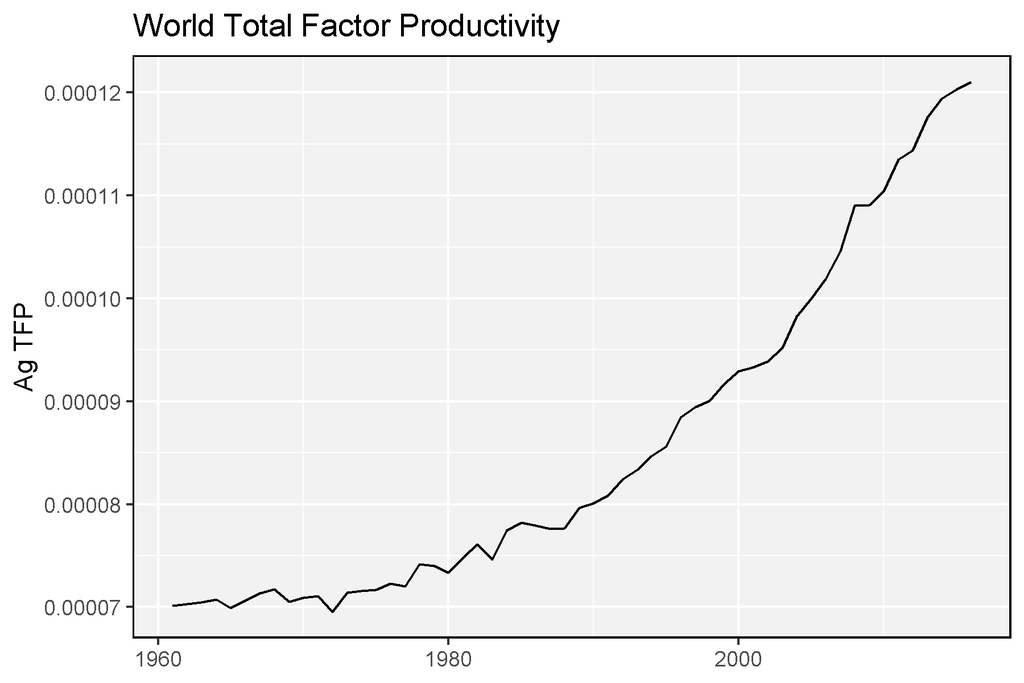

```r
# Prep data for an example plot
xx <- xx %>% filter(Area == "World", Measurement == "Ag TFP")
# Plot
mp <- ggplot(xx, aes(x = Year, y = Value / 1000000)) +
  geom_line() +
  theme_agData() +
  labs(title = "World Total Factor Productivity",
       y = "Ag TFP", x = NULL)
ggsave("Intro_agData_USDA_TFP.png", mp, width = 6, height = 4)
```

# agData_ISAAA_Area

```r
# Get Data
xx <- agData_ISAAA_Area %>% filter(Measurement == "Area") %>%
  as_tibble()
xx
```

```
## # A tibble: 23 x 5
##    Area   Year Measurement Unit        Value
##    <chr> <dbl> <chr>       <chr>       <dbl>
##  1 World  1996 Area        Hectares  2800000
##  2 World  1997 Area        Hectares 12800000
##  3 World  1998 Area        Hectares 27800000
##  4 World  1999 Area        Hectares 39900000
##  5 World  2000 Area        Hectares 44200000
##  6 World  2001 Area        Hectares 52600000
##  7 World  2002 Area        Hectares 58700000
##  8 World  2003 Area        Hectares 67700000
##  9 World  2004 Area        Hectares 81000000
## 10 World  2005 Area        Hectares 90000000
## # ... with 13 more rows
```

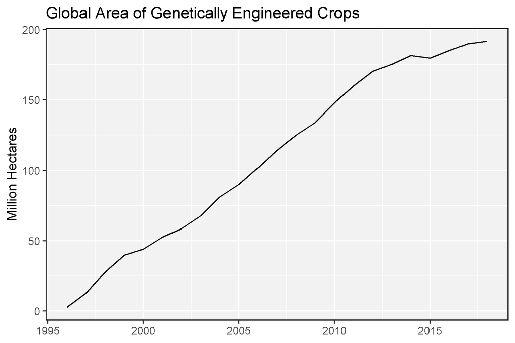

```r
# Plot
mp <- ggplot(xx, aes(x = Year, y = Value / 1000000)) +
  geom_line() +
  theme_agData() +
  labs(title = "Global Area of Genetically Engineered Crops",
       y = "Million Hectares", x = NULL)
ggsave("Intro_agData_ISAAA_Area.png", mp, width = 6, height = 4)
```

# agData_ISAAA_Country

```r
# Get Data
xx <- agData_ISAAA_Country %>% as_tibble()
xx
```

```
## # A tibble: 1,787 x 5
##    Area       Year Measurement Unit       Value
##    <chr>     <dbl> <chr>       <chr>      <dbl>
##  1 USA        1996 Area        Hectares 1500000
##  2 China      1996 Area        Hectares 1100000
##  3 Argentina  1996 Area        Hectares  100000
##  4 Canada     1996 Area        Hectares  100000
##  5 Australia  1996 Area        Hectares  100000
##  6 Mexico     1996 Area        Hectares  100000
##  7 USA        1997 Area        Hectares 8100000
##  8 Argentina  1997 Area        Hectares 1400000
##  9 Canada     1997 Area        Hectares 1300000
## 10 Australia  1997 Area        Hectares  100000
## # ... with 1,777 more rows
```

```r
# List Area
xx %>% distinct(Area)
```

```
## # A tibble: 43 x 1
##    Area
##    <chr>
##  1 USA
##  2 China
##  3 Argentina
##  4 Canada
##  5 Australia
##  6 Mexico
##  7 Spain
##  8 France
##  9 South Africa
## 10 Portugal
## # ... with 33 more rows
```

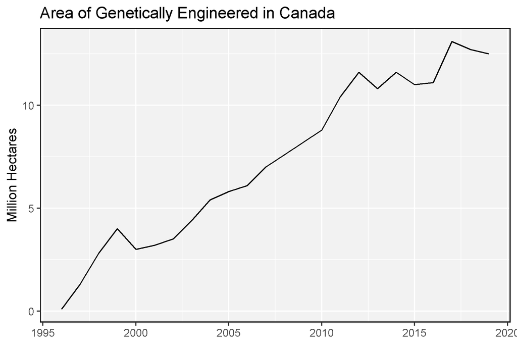

```r
# Prep data for an example plot
xx <- xx %>% filter(Area == "Canada", Measurement == "Area")
# Plot
mp <- ggplot(xx, aes(x = Year, y = Value / 1000000)) +
  geom_line() +
  theme_agData() +
  labs(title = "Area of Genetically Engineered in Canada",
       y = "Million Hectares", x = NULL)
ggsave("Intro_agData_ISAAA_Country.png", mp, width = 6, height = 4)
```

# agData_ISAAA_Crop

```r
# Get Data
xx <- agData_ISAAA_Crop %>% as_tibble()
xx
```

```
## # A tibble: 614 x 5
##     Year Crop    Measurement Unit       Value
##    <dbl> <chr>   <chr>       <chr>      <dbl>
##  1  1996 Soybean Area        Hectares  500000
##  2  1996 Maize   Area        Hectares  300000
##  3  1996 Tabacco Area        Hectares 1000000
##  4  1996 Cotton  Area        Hectares  800000
##  5  1996 Canola  Area        Hectares  100000
##  6  1996 Tomato  Area        Hectares  100000
##  7  1996 Potato  Area        Hectares  100000
##  8  1997 Soybean Area        Hectares 5100000
##  9  1997 Maize   Area        Hectares 3200000
## 10  1997 Tabacco Area        Hectares 1600000
## # ... with 604 more rows
```

```r
# List Crops
xx %>% distinct(Crop)
```

```
## # A tibble: 13 x 1
##    Crop
##    <chr>
##  1 Soybean
##  2 Maize
##  3 Tabacco
##  4 Cotton
##  5 Canola
##  6 Tomato
##  7 Potato
##  8 Squash
##  9 Papaya
## 10 Rice
## 11 Others
## 12 Alfalfa
## 13 Sugar beet
```

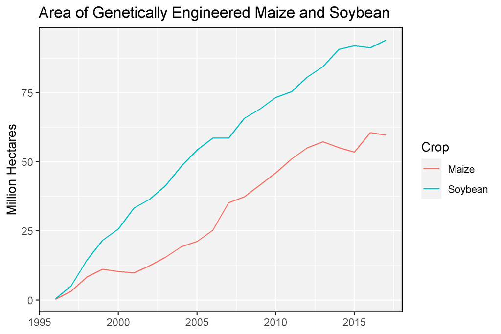

```r
# Prep data for an example plot
xx <- xx %>% filter(Crop %in% c("Soybean","Maize"),
                    Measurement == "Area")
# Plot
mp <- ggplot(xx, aes(x = Year, y = Value / 1000000, color = Crop)) +
  geom_line() +
  theme_agData() +
  labs(title = "Area of Genetically Engineered Maize and Soybean",
       y = "Million Hectares", x = NULL)
ggsave("Intro_agData_ISAAA_Crop.png", mp, width = 6, height = 4)
```

# agData_ISAAA_CropPercent

```r
# Get Data
xx <- agData_ISAAA_CropPercent %>% as_tibble()
xx
```

```
## # A tibble: 213 x 5
##     Year Crop    Measurement Unit         Value
##    <dbl> <chr>   <chr>       <chr>        <dbl>
##  1  1999 Soybean Area        Hectares  72000000
##  2  1999 Canola  Area        Hectares  25000000
##  3  1999 Cotton  Area        Hectares  34000000
##  4  1999 Maize   Area        Hectares 140000000
##  5  2000 Soybean Area        Hectares  72000000
##  6  2000 Cotton  Area        Hectares  34000000
##  7  2000 Canola  Area        Hectares  25000000
##  8  2000 Maize   Area        Hectares 140000000
##  9  2001 Soybean Area        Hectares  72000000
## 10  2001 Cotton  Area        Hectares  34000000
## # ... with 203 more rows
```

```r
# List Crops
xx %>% distinct(Crop)
```

```
## # A tibble: 5 x 1
##   Crop
##   <chr>
## 1 Soybean
## 2 Canola
## 3 Cotton
## 4 Maize
## 5 Others
```

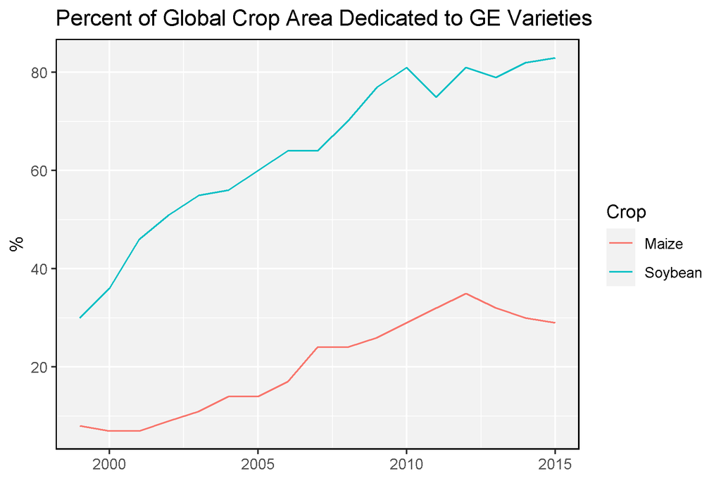

```r
# Prep data for an example plot
xx <- xx %>% filter(Crop %in% c("Soybean","Maize"),
                    Measurement == "Percent")
# Plot
mp <- ggplot(xx, aes(x = Year, y = Value, color = Crop)) +
  geom_line() +
  theme_agData() +
  labs(title = "Percent of Global Crop Area Dedicated to GE Varieties",
       y = "%", x = NULL)
ggsave("Intro_agData_ISAAA_CropPercent.png", mp, width = 6, height = 4)
```

# agData_ISAAA_DVDDVG

```r
# Get Data
xx <- agData_ISAAA_DVDDVG %>% as_tibble()
xx
```

```
## # A tibble: 88 x 5
##    Area                      Year Measurement Unit        Value
##    <chr>                    <dbl> <chr>       <chr>       <dbl>
##  1 Industrialized countries  1996 Area        Hectares  1600000
##  2 Developing countries      1996 Area        Hectares  1200000
##  3 Industrialized countries  1997 Area        Hectares  9500000
##  4 Developing countries      1997 Area        Hectares  3300000
##  5 Industrialized countries  1998 Area        Hectares 23400000
##  6 Developing countries      1998 Area        Hectares  4400000
##  7 Industrialized countries  1999 Area        Hectares 32800000
##  8 Developing countries      1999 Area        Hectares  7100000
##  9 Industrialized countries  2000 Area        Hectares 33500000
## 10 Developing countries      2000 Area        Hectares 10700000
## # ... with 78 more rows
```

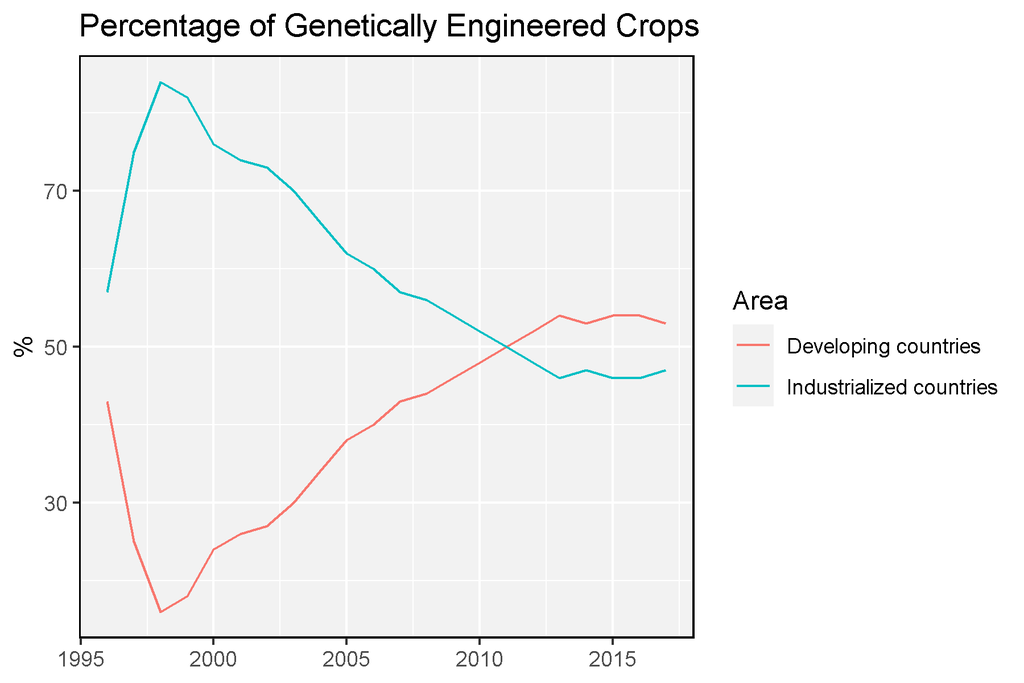

```r
# Prep data
xx <- xx %>% filter(Unit == "Percent")
# Plot
mp <- ggplot(xx, aes(x = Year, y = Value, color = Area)) +
  geom_line() +
  theme_agData() +
  labs(title = "Percentage of Genetically Engineered Crops",
       y = "%", x = NULL)
ggsave("Intro_agData_ISAAA_DVDDVG.png", mp, width = 6, height = 4)
```

# agData_ISAAA_Value

```r
# Get Data
xx <- agData_ISAAA_Value %>% as_tibble()
xx
```

```
## # A tibble: 22 x 3
##     Year Unit        Value
##    <dbl> <chr>       <dbl>
##  1  1996 Billion USD 0.093
##  2  1997 Billion USD 0.591
##  3  1998 Billion USD 1.56
##  4  1999 Billion USD 2.35
##  5  2000 Billion USD 2.43
##  6  2001 Billion USD 2.93
##  7  2002 Billion USD 3.47
##  8  2003 Billion USD 4.05
##  9  2004 Billion USD 5.09
## 10  2005 Billion USD 5.71
## # ... with 12 more rows
```

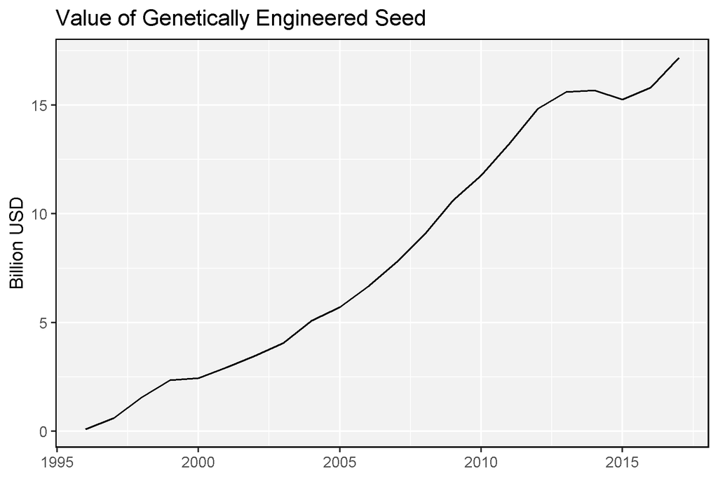

```r
# Plot
mp <- ggplot(xx, aes(x = Year, y = Value)) +
  geom_line() +
  theme_agData() +
  labs(title = "Value of Genetically Engineered Seed",
       y = "Billion USD", x = NULL)
ggsave("Intro_agData_ISAAA_Value.png", mp, width = 6, height = 4)
```

# agData_UK_Yields

```r
# Get Data
xx <- agData_UK_Yields %>% as_tibble()
xx
```

```
## # A tibble: 1,818 x 6
##    Area           Crop   Year Measurement Unit      Value
##    <chr>          <fct> <int> <fct>       <fct>     <dbl>
##  1 United Kingdom Wheat  1270 Yield       tonnes/ha 0.522
##  2 United Kingdom Wheat  1271 Yield       tonnes/ha 0.471
##  3 United Kingdom Wheat  1272 Yield       tonnes/ha 0.685
##  4 United Kingdom Wheat  1273 Yield       tonnes/ha 0.483
##  5 United Kingdom Wheat  1274 Yield       tonnes/ha 0.443
##  6 United Kingdom Wheat  1275 Yield       tonnes/ha 0.788
##  7 United Kingdom Wheat  1276 Yield       tonnes/ha 0.482
##  8 United Kingdom Wheat  1277 Yield       tonnes/ha 0.669
##  9 United Kingdom Wheat  1278 Yield       tonnes/ha 0.845
## 10 United Kingdom Wheat  1279 Yield       tonnes/ha 0.482
## # ... with 1,808 more rows
```

```r
# List Measurements
xx %>% distinct(Measurement, Unit)
```

```
## # A tibble: 1 x 2
##   Measurement Unit
##   <fct>       <fct>
## 1 Yield       tonnes/ha
```

```r
# List Crops
xx %>% distinct(Crop)
```

```
## # A tibble: 3 x 1
##   Crop
##   <fct>
## 1 Wheat
## 2 Barley
## 3 Oats
```

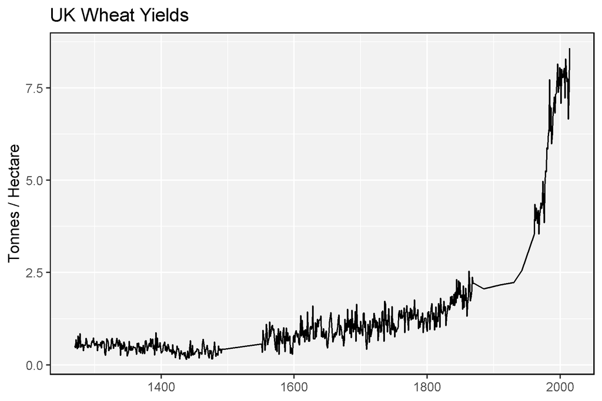

```r
# Prep data
xx <- xx %>% filter(Crop == "Wheat", !is.na(Value))
# Plot
mp <- ggplot(xx, aes(x = Year, y = Value)) +
  geom_line() +
  theme_agData() +
  labs(title = "UK Wheat Yields", y = "Tonnes / Hectare", x = NULL)
ggsave("Intro_agData_UK_Yields.png", mp, width = 6, height = 4)
```

# agData_MaizeContest

```r
# Get Data
xx <- agData_MaizeContest %>% as_tibble()
xx
```

```
## # A tibble: 108 x 5
##     Year Crop  Measurement                         Unit         Value
##    <dbl> <chr> <chr>                               <chr>        <dbl>
##  1  2010 Maize A Non-Irrigated                     Bushels/Acre  306.
##  2  2010 Maize AA Non-Irrigated                    Bushels/Acre  300.
##  3  2010 Maize A No-Till/Strip-Till Non-Irrigated  Bushels/Acre  294.
##  4  2010 Maize AA No-Till/Strip-Till Non-Irrigated Bushels/Acre  300.
##  5  2010 Maize No-Till/Strip-Till Irrigated        Bushels/Acre  368.
##  6  2010 Maize Irrigated                           Bushels/Acre  341
##  7  2011 Maize A Non-Irrigated                     Bushels/Acre  288.
##  8  2011 Maize AA Non-Irrigated                    Bushels/Acre  322.
##  9  2011 Maize A No-Till/Strip-Till Non-Irrigated  Bushels/Acre  294.
## 10  2011 Maize AA No-Till/Strip-Till Non-Irrigated Bushels/Acre  298.
## # ... with 98 more rows
```

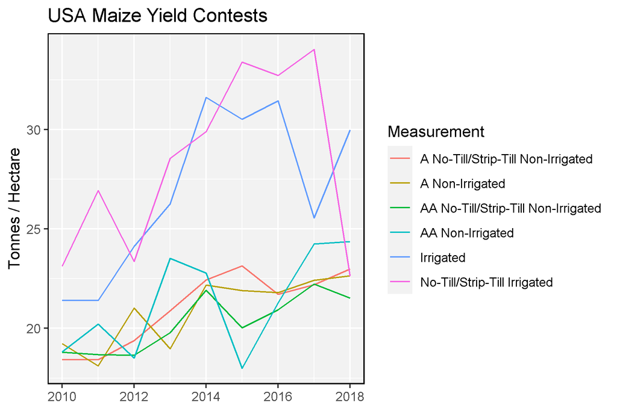

```r
# Prep Data
xx <- xx %>% filter(Unit == "Tonnes/Hectare")
# Plot
mp <- ggplot(xx, aes(x = Year, y = Value, color = Measurement)) +
  geom_line() +
  theme_agData() +
  labs(title = "USA Maize Yield Contests",
       y = "Tonnes / Hectare", x = NULL)
ggsave("Intro_agData_MaizeContest.png", mp, width = 6, height = 4)
```